# Multi-Class Classification Model for Human Activity Recognition with Smartphone Using R Take 1

David Lowe

October 17, 2018

Template Credit: Adapted from a template made available by Dr. Jason Brownlee of Machine Learning Mastery. [http://machinelearningmastery.com/]

SUMMARY: The purpose of this project is to construct a prediction model using various machine learning algorithms and to document the end-to-end steps using a template. The Human Activities with Smartphone Dataset is a multi-class classification situation where we are trying to predict one of the six possible outcomes.

INTRODUCTION: Researchers collected the datasets from experiments that consist of a group of 30 volunteers with each person performed six activities wearing a smartphone on the waist. With its embedded accelerometer and gyroscope, the research captured measurement for the activities of WALKING, WALKING_UPSTAIRS, WALKING_DOWNSTAIRS, SITTING, STANDING, LAYING. The dataset has been randomly partitioned into two sets, where 70% of the volunteers were selected for generating the training data and 30% the test data.

For this iteration, the script focuses on evaluating various machine learning algorithms and identify the algorithm that produces the best accuracy metric.

From the model-building activities, the Stochastic Gradient Boosting ensemble algorithm achieved the top-notch training and validation results. For the project, Stochastic Gradient Boosting should be considered for further modeling or production use.

Dataset Used: Human Activity Recognition Using Smartphone Data Set

Dataset ML Model: Multi-class classification with numerical attributes

Dataset Reference: https://archive.ics.uci.edu/ml/datasets/Human+Activity+Recognition+Using+Smartphones

One potential source of performance benchmarks: https://www.kaggle.com/uciml/human-activity-recognition-with-smartphones

The project aims to touch on the following areas:

1. Document a predictive modeling problem end-to-end.
2. Explore data cleaning and transformation options
3. Explore non-ensemble and ensemble algorithms for baseline model performance
4. Explore algorithm tuning techniques for improving model performance

Any predictive modeling machine learning project genrally can be broken down into about six major tasks:

1. Prepare Problem
2. Summarize Data
3. Prepare Data
4. Model and Evaluate Algorithms
5. Improve Accuracy or Results
6. Finalize Model and Present Results

## 1. Prepare Problem

### 1.a) Load libraries

```r
startTimeScript <- proc.time()
library(caret)
```

```r
library(corrplot)
library(parallel)
```

### 1.b) Load dataset

```r
widthVector <- rep(16, 561)
colNames <- paste0("attr",1:561)
x_train <- read.fwf("X_train.txt", widths = widthVector, col.names = colNames)
y_train <- read.csv("y_train.txt", header = FALSE, col.names = c("targetVar"))
y_train$targetVar <- as.factor(y_train$targetVar)
entireDataset <- cbind(x_train, y_train)

x_test <- read.fwf("X_test.txt", widths = widthVector, col.names = colNames)
y_test <- read.csv("y_test.txt", header = FALSE, col.names = c("targetVar"))
y_test$targetVar <- as.factor(y_test$targetVar)
validation <- cbind(x_test, y_test)
```

### 1.c) Set up the key parameters to be used in the script

```r
# Create one random seed number for reproducible results
seedNum <- 888
set.seed(seedNum)

# Use variable totCol to hold the number of columns in the dataframe
totCol <- ncol(entireDataset)
```

```r
# Set up a variable for the total number of attribute columns (totAttr)
totAttr <- totCol-1
# Set up the number of row and columns for visualization display. dispRow * dispCol should be >= totAttr
dispCol <- 5
if (totAttr%%dispCol == 0) {
dispRow <- totAttr%/%dispCol
} else {
dispRow <- (totAttr%/%dispCol) + 1
}
cat("Will attempt to create graphics grid (col x row): ", dispCol, ' by ', dispRow)
```

```
## Will attempt to create graphics grid (col x row):  5  by  113
```

## 2. Summarize Data

To gain a better understanding of the data that we have on-hand, we will leverage a number of descriptive statistics and data visualization techniques. The plan is to use the results to consider new questions, review assumptions, and validate hypotheses that we can investigate later with specialized models.

### 2.a) Descriptive statistics

#### 2.a.i) Peek at the data itself.

```r
head(entireDataset)
```

```
##       attr1       attr2      attr3      attr4      attr5      attr6
## 1 0.2885845 -0.02029417 -0.1329051 -0.9952786 -0.9831106 -0.9135264
## 2 0.2784188 -0.01641057 -0.1235202 -0.9982453 -0.9753002 -0.9603220
## 3 0.2796531 -0.01946716 -0.1134617 -0.9953796 -0.9671870 -0.9789440
## 4 0.2791739 -0.02620065 -0.1232826 -0.9960915 -0.9834027 -0.9906751
## 5 0.2766288 -0.01656965 -0.1153619 -0.9981386 -0.9808173 -0.9904816
## 6 0.2771988 -0.01009785 -0.1051373 -0.9973350 -0.9904868 -0.9954200
##        attr7      attr8      attr9     attr10     attr11     attr12
## 1 -0.9951121 -0.9831846 -0.9235270 -0.9347238 -0.5673781 -0.7444125
## 2 -0.9988072 -0.9749144 -0.9576862 -0.9430675 -0.5578513 -0.8184087
## 3 -0.9965199 -0.9636684 -0.9774686 -0.9386916 -0.5578513 -0.8184087
## 4 -0.9970995 -0.9827498 -0.9893025 -0.9386916 -0.5761589 -0.8297115
## 5 -0.9983211 -0.9796719 -0.9904411 -0.9424691 -0.5691738 -0.8247053
## 6 -0.9976274 -0.9902177 -0.9955489 -0.9424691 -0.5656839 -0.8227661
##      attr13    attr14    attr15     attr16     attr17     attr18
```

[output cut: 636 more lines]

#### 2.a.ii) Dimensions of the dataset.

```r
dim(entireDataset)
```

```
## [1] 7352  562
```

#### 2.a.iii) Types of the attributes.

```r
sapply(entireDataset, class)
```

[output not shown]

[output cut: 107 more lines]

[output not shown]

#### 2.a.iv) Statistical summary of all attributes.

```r
summary(entireDataset)
```

```
##      attr1             attr2              attr3              attr4
##  Min.   :-1.0000   Min.   :-1.00000   Min.   :-1.00000   Min.   :-1.0000
##  1st Qu.: 0.2630   1st Qu.:-0.02486   1st Qu.:-0.12099   1st Qu.:-0.9928
##  Median : 0.2772   Median :-0.01722   Median :-0.10868   Median :-0.9462
##  Mean   : 0.2745   Mean   :-0.01770   Mean   :-0.10914   Mean   :-0.6054
##  3rd Qu.: 0.2885   3rd Qu.:-0.01078   3rd Qu.:-0.09779   3rd Qu.:-0.2428
##  Max.   : 1.0000   Max.   : 1.00000   Max.   : 1.00000   Max.   : 1.0000
##      attr5              attr6             attr7             attr8
##  Min.   :-0.99987   Min.   :-1.0000   Min.   :-1.0000   Min.   :-1.0000
##  1st Qu.:-0.97813   1st Qu.:-0.9802   1st Qu.:-0.9936   1st Qu.:-0.9782
##  Median :-0.85190   Median :-0.8594   Median :-0.9507   Median :-0.8573
##  Mean   :-0.51094   Mean   :-0.6048   Mean   :-0.6305   Mean   :-0.5269
##  3rd Qu.:-0.03423   3rd Qu.:-0.2624   3rd Qu.:-0.2927   3rd Qu.:-0.0667
##  Max.   : 0.91624   Max.   : 1.0000   Max.   : 1.0000   Max.   : 0.9677
##      attr9             attr10             attr11             attr12
##  Min.   :-1.0000   Min.   :-1.00000   Min.   :-1.00000   Min.   :-1.0000
##  1st Qu.:-0.9803   1st Qu.:-0.93622   1st Qu.:-0.56356   1st Qu.:-0.8127
##  Median :-0.8571   Median :-0.88164   Median :-0.47968   Median :-0.7365
##  Mean   :-0.6062   Mean   :-0.46860   Mean   :-0.30604   Mean   :-0.5571
##  3rd Qu.:-0.2657   3rd Qu.:-0.01713   3rd Qu.:-0.06536   3rd Qu.:-0.3320
##  Max.   : 1.0000   Max.   : 1.00000   Max.   : 1.00000   Max.   : 1.0000
##      attr13            attr14            attr15            attr16
##  Min.   :-1.0000   Min.   :-1.0000   Min.   :-1.0000   Min.   :-1.0000
##  1st Qu.: 0.1971   1st Qu.: 0.1018   1st Qu.: 0.3898   1st Qu.:-0.9830
##  Median : 0.7921   Median : 0.6277   Median : 0.7781   Median :-0.8855
##  Mean   : 0.5236   Mean   : 0.3874   Mean   : 0.5944   Mean   :-0.5476
##  3rd Qu.: 0.8444   3rd Qu.: 0.6856   3rd Qu.: 0.8373   3rd Qu.:-0.1074
##  Max.   : 1.0000   Max.   : 1.0000   Max.   : 1.0000   Max.   : 1.0000
##      attr17            attr18            attr19            attr20
##  Min.   :-1.0000   Min.   :-1.0000   Min.   :-1.0000   Min.   :-1.0000
##  1st Qu.:-0.9999   1st Qu.:-0.9998   1st Qu.:-0.9995   1st Qu.:-0.9944
##  Median :-0.9980   Median :-0.9941   Median :-0.9855   Median :-0.9579
##  Mean   :-0.8200   Mean   :-0.9019   Mean   :-0.8458   Mean   :-0.6843
##  3rd Qu.:-0.7107   3rd Qu.:-0.8167   3rd Qu.:-0.7480   3rd Qu.:-0.3932
##  Max.   : 1.0000   Max.   : 1.0000   Max.   : 1.0000   Max.   : 1.0000
##      attr21            attr22            attr23             attr24
##  Min.   :-1.0000   Min.   :-1.0000   Min.   :-1.00000   Min.   :-1.0000
##  1st Qu.:-0.9822   1st Qu.:-0.9796   1st Qu.:-0.57344   1st Qu.:-0.5596
##  Median :-0.8961   Median :-0.8645   Median :-0.07337   Median :-0.1368
##  Mean   :-0.6438   Mean   :-0.6311   Mean   :-0.10299   Mean   :-0.1379
```

[output cut: 995 more lines]

```
##  Max.   : 1.000000   Max.   : 1.000000   Max.   : 0.998702
##     attr558              attr559           attr560
##  Min.   :-1.0000000   Min.   :-1.0000   Min.   :-1.00000
##  1st Qu.:-0.3763415   1st Qu.:-0.8121   1st Qu.:-0.01788
##  Median :-0.0003679   Median :-0.7094   Median : 0.18207
##  Mean   :-0.0059809   Mean   :-0.4895   Mean   : 0.05859
##  3rd Qu.: 0.3593677   3rd Qu.:-0.5091   3rd Qu.: 0.24835
##  Max.   : 0.9960782   Max.   : 1.0000   Max.   : 0.47816
##     attr561          targetVar
##  Min.   :-1.000000   1:1226
##  1st Qu.:-0.143414   2:1073
##  Median : 0.003181   3: 986
##  Mean   :-0.056515   4:1286
##  3rd Qu.: 0.107659   5:1374
##  Max.   : 1.000000   6:1407
```

#### 2.a.v) Summarize the levels of the class attribute.

```r
entireDataset_x <- entireDataset[,1:(totCol-1)]
entireDataset_y <- entireDataset[,totCol]
cbind(freq=table(entireDataset_y), percentage=prop.table(table(entireDataset_y))*100)
```

```
##   freq percentage
## 1 1226   16.67573
## 2 1073   14.59467
## 3  986   13.41132
## 4 1286   17.49184
## 5 1374   18.68879
## 6 1407   19.13765
```

#### 2.a.vi) Count missing values.

```r
sapply(entireDataset, function(x) sum(is.na(x)))
```

[output not shown]

[output cut: 107 more lines]

[output not shown]

### 2.b) Data visualizations

#### 2.b.i) Univariate plots to better understand each attribute.

```r
# Boxplots for each attribute
#par(mfrow=c(dispRow,dispCol))
#for(i in 1:totAttr) {
#   boxplot(entireDataset[,i], main=names(entireDataset)[i])
#}
```

```r
# Histograms each attribute
#par(mfrow=c(dispRow,dispCol))
#for(i in 1:totAttr) {
#   hist(entireDataset[,i], main=names(entireDataset)[i])
#}
```

```r
# Density plot for each attribute
#par(mfrow=c(dispRow,dispCol))
#for(i in 1:totAttr) {
#   plot(density(entireDataset[,i]), main=names(entireDataset)[i])
#}
```

#### 2.b.ii) Multivariate plots to better understand the relationships between attributes

```r
# Scatterplot matrix colored by class
#pairs(targetVar~., data=entireDataset, col=entireDataset$targetVar)
```

```r
# Box and whisker plots for each attribute by class
#scales <- list(x=list(relation="free"), y=list(relation="free"))
#featurePlot(x=entireDataset_x, y=entireDataset_y, plot="box", scales=scales)
```

```r
# Density plots for each attribute by class value
#featurePlot(x=entireDataset_x, y=entireDataset_y, plot="density", scales=scales)
```

```r
# Correlation plot
#correlations <- cor(entireDataset_x)
#corrplot(correlations, method="circle")
```

## 3. Prepare Data

Some dataset may require additional preparation activities that will best exposes the structure of the problem and the relationships between the input attributes and the output variable. Some data-prep tasks might include:

- Cleaning data by removing duplicates, marking missing values and even imputing missing values.
- Feature selection where redundant features may be removed.
- Data transforms where attributes are scaled or redistributed in order to best expose the structure of the problem later to learning algorithms.

### 3.a) Data Cleaning

```r
# Not applicable for this iteration of the project.

# Mark missing values
#invalid <- 0
#entireDataset$some_col[entireDataset$some_col==invalid] <- NA

# Impute missing values
#entireDataset$some_col <- with(entireDataset, impute(some_col, mean))
```

### 3.b) Feature Selection

```r
# Not applicable for this iteration of the project.
```

### 3.c) Data Transforms

```r
# Not applicable for this iteration of the project.
```

### 3.d) Split-out training and validation datasets

We create a training dataset (variable name “training”) and a validation dataset (variable name “validation”).

```r
set.seed(seedNum)

# Create a list of the rows in the original dataset we can use for training
#training_index <- createDataPartition(entireDataset$targetVar, p=0.70, list=FALSE)
# Use 70% of data to training and testing the models
#training <- entireDataset[training_index,]
# Select the remaining 30% of the data for validation
#validation <- entireDataset[-training_index,]

training <- entireDataset
rm(entireDataset); gc()
```

```
##            used  (Mb) gc trigger  (Mb) max used  (Mb)
## Ncells  2440225 130.4    8149095 435.3  5944135 317.5
## Vcells 11796514  90.1   33181668 253.2 33181666 253.2
```

```r
dim(training)
```

```
## [1] 7352  562
```

```r
dim(validation)
```

```
## [1] 2947  562
```

```r
proc.time()-startTimeScript
```

```
##    user  system elapsed
##   73.72  213.08  287.89
```

## 4. Model and Evaluate Algorithms

After the data-prep, we next work on finding a workable model by evaluating a subset of machine learning algorithms that are good at exploiting the structure of the training. The typical evaluation tasks include:

- Defining test options such as cross validation and the evaluation metric to use.
- Spot checking a suite of linear and nonlinear machine learning algorithms.
- Comparing the estimated accuracy of algorithms.

For this project, we will evaluate one linear, three non-linear, and three ensemble algorithms:

Linear Algorithm: Linear Discriminant Analysis

Non-Linear Algorithms: Decision Trees (CART), k-Nearest Neighbors, and Support Vector Machine

Ensemble Algorithms: Bagged CART, Random Forest, and Stochastic Gradient Boosting

The random number seed is reset before each run to ensure that the evaluation of each algorithm is performed using the same data splits. It ensures the results are directly comparable.

### 4.a) Set test options and evaluation metric

```r
# Run algorithms using 10-fold cross validation
control <- trainControl(method="repeatedcv", number=10, repeats=3)
metricTarget <- "Accuracy"
```

### 4.b) Generate models using linear algorithms

```r
# Linear Discriminant Analysis (Classification)
startTimeModule <- proc.time()
set.seed(seedNum)
fit.lda <- train(targetVar~., data=training, method="lda", metric=metricTarget, trControl=control)
```

[output not shown]

```r
proc.time()-startTimeModule
```

```
##    user  system elapsed
##  297.72    8.75  306.74
```

### 4.c) Generate models using nonlinear algorithms

```r
# Decision Tree - CART (Regression/Classification)
startTimeModule <- proc.time()
set.seed(seedNum)
fit.cart <- train(targetVar~., data=training, method="rpart", metric=metricTarget, trControl=control)
proc.time()-startTimeModule
```

```
##    user  system elapsed
##   91.06    5.23   96.45
```

```r
# k-Nearest Neighbors (Regression/Classification)
startTimeModule <- proc.time()
set.seed(seedNum)
fit.knn <- train(targetVar~., data=training, method="knn", metric=metricTarget, trControl=control)
proc.time()-startTimeModule
```

```
##     user   system  elapsed
## 12152.86     5.86 12170.66
```

```r
# Support Vector Machine (Regression/Classification)
startTimeModule <- proc.time()
set.seed(seedNum)
fit.svm <- train(targetVar~., data=training, method="svmRadial", metric=metricTarget, trControl=control)
proc.time()-startTimeModule
```

```
##    user  system elapsed
## 2352.56   74.06 2428.83
```

### 4.d) Generate models using ensemble algorithms

In this section, we will explore the use and tuning of ensemble algorithms to see whether we can improve the results.

```r
# Bagged CART (Regression/Classification)
startTimeModule <- proc.time()
set.seed(seedNum)
fit.bagcart <- train(targetVar~., data=training, method="treebag", metric=metricTarget, trControl=control)
proc.time()-startTimeModule
```

```
##    user  system elapsed
## 2795.25   59.87 2857.38
```

```r
# Random Forest (Regression/Classification)
startTimeModule <- proc.time()
set.seed(seedNum)
fit.rf <- train(targetVar~., data=training, method="rf", metric=metricTarget, trControl=control)
proc.time()-startTimeModule
```

```
##     user   system  elapsed
## 36993.32    23.39 37053.27
```

```r
# Stochastic Gradient Boosting (Regression/Classification)
startTimeModule <- proc.time()
set.seed(seedNum)
fit.gbm <- train(targetVar~., data=training, method="gbm", metric=metricTarget, trControl=control, verbose=F)
proc.time()-startTimeModule
```

```
##     user   system  elapsed
## 10315.58    12.59 10340.26
```

### 4.e) Compare baseline algorithms

```r
results <- resamples(list(LDA=fit.lda, CART=fit.cart, kNN=fit.knn, SVM=fit.svm, BagCART=fit.bagcart, RF=fit.rf, GBM=fit.gbm))
summary(results)
```

```
##
## Call:
## summary.resamples(object = results)
##
## Models: LDA, CART, kNN, SVM, BagCART, RF, GBM
## Number of resamples: 30
##
## Accuracy
##              Min.   1st Qu.    Median      Mean   3rd Qu.      Max. NA's
## LDA     0.9646739 0.9782313 0.9802461 0.9805940 0.9837067 0.9905149    0
## CART    0.5433604 0.5454855 0.6641711 0.6133216 0.6739130 0.6784741    0
## kNN     0.9564626 0.9672690 0.9687924 0.9694410 0.9727891 0.9795640    0
## SVM     0.9700680 0.9755185 0.9795954 0.9790077 0.9823549 0.9877551    0
## BagCART 0.9578231 0.9659864 0.9701086 0.9693503 0.9737738 0.9823129    0
## RF      0.9687075 0.9795988 0.9809394 0.9819096 0.9837122 0.9905020    0
## GBM     0.9795918 0.9850594 0.9877551 0.9875313 0.9891452 0.9945799    0
##
## Kappa
##              Min.   1st Qu.    Median      Mean   3rd Qu.      Max. NA's
## LDA     0.9574740 0.9737945 0.9762211 0.9766405 0.9803858 0.9885833    0
## CART    0.4440361 0.4464444 0.5923597 0.5297246 0.6039890 0.6093764    0
## kNN     0.9475820 0.9605828 0.9624303 0.9632082 0.9672431 0.9754006    0
## SVM     0.9639668 0.9705378 0.9754372 0.9747332 0.9787617 0.9852608    0
## BagCART 0.9492352 0.9590540 0.9640159 0.9631060 0.9684266 0.9787061    0
## RF      0.9623438 0.9754452 0.9770557 0.9782248 0.9803921 0.9885664    0
## GBM     0.9754384 0.9820172 0.9852620 0.9849914 0.9869353 0.9934758    0
```

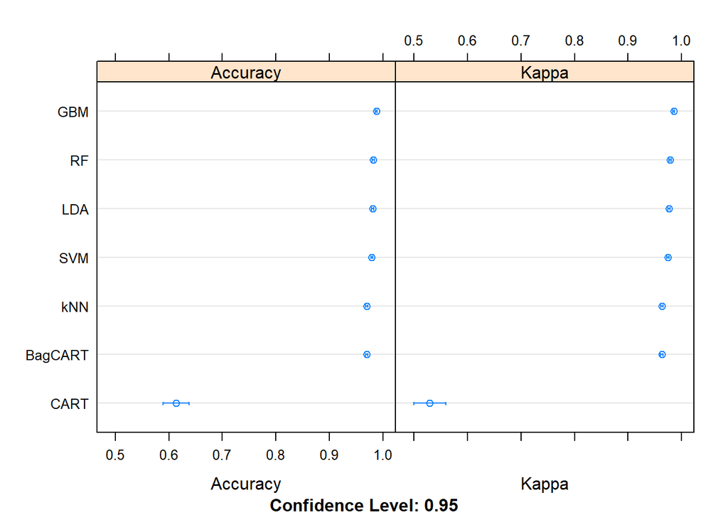

```r
dotplot(results)
```

```r
cat('The average accuracy from all models is:',
    mean(c(results$values$`LR~Accuracy`,results$values$`CART~Accuracy`,results$values$`kNN~Accuracy`,results$values$`SVM~Accuracy`,results$values$`BagCART~Accuracy`,results$values$`RF~Accuracy`,results$values$`GBM~Accuracy`)))
```

```
## The average accuracy from all models is: 0.9167602
```

## 5. Improve Accuracy or Results

After we achieve a short list of machine learning algorithms with good level of accuracy, we can leverage ways to improve the accuracy of the models.

### 5.a) Algorithm Tuning

Finally, we will tune the best-performing algorithms from each group further and see whether we can get more accuracy out of them.

```r
# Tuning algorithm #1 - Linear Discriminant Analysis
startTimeModule <- proc.time()
set.seed(seedNum)
fit.final1 <- fit.lda
print(fit.final1)
```

```
## Linear Discriminant Analysis
##
## 7352 samples
##  561 predictor
##    6 classes: '1', '2', '3', '4', '5', '6'
##
## No pre-processing
## Resampling: Cross-Validated (10 fold, repeated 3 times)
## Summary of sample sizes: 6619, 6617, 6616, 6618, 6615, 6617, ...
## Resampling results:
##
##   Accuracy  Kappa
##   0.980594  0.9766405
```

```r
proc.time()-startTimeModule
```

```
##    user  system elapsed
##       0       0       0
```

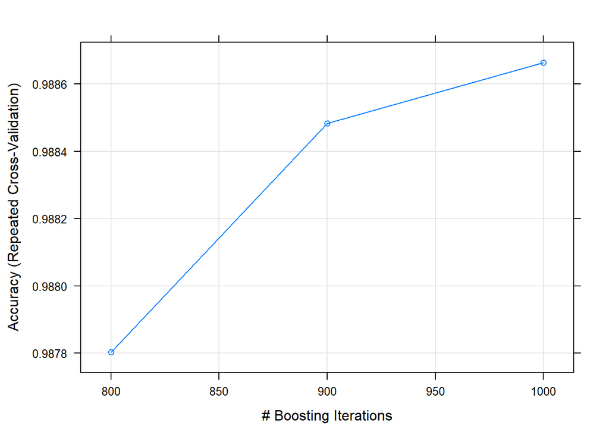

```r
# Tuning algorithm #2 - Stochastic Gradient Boosting
startTimeModule <- proc.time()
set.seed(seedNum)
grid <- expand.grid(.n.trees=c(800, 900, 1000), .shrinkage=c(0.1), .interaction.depth=c(1), .n.minobsinnode=c(10))
fit.final2 <- train(targetVar~., data=training, method="gbm", metric=metricTarget, tuneGrid=grid, trControl=control, verbose=F)
plot(fit.final2)
```

```r
print(fit.final2)
```

```
## Stochastic Gradient Boosting
##
## 7352 samples
##  561 predictor
##    6 classes: '1', '2', '3', '4', '5', '6'
##
## No pre-processing
## Resampling: Cross-Validated (10 fold, repeated 3 times)
## Summary of sample sizes: 6619, 6617, 6616, 6618, 6615, 6617, ...
## Resampling results across tuning parameters:
##
##   n.trees  Accuracy   Kappa
##    800     0.9878027  0.9853180
##    900     0.9884824  0.9861361
##   1000     0.9886638  0.9863543
##
## Tuning parameter 'interaction.depth' was held constant at a value of
##  1
## Tuning parameter 'shrinkage' was held constant at a value of 0.1
##
## Tuning parameter 'n.minobsinnode' was held constant at a value of 10
## Accuracy was used to select the optimal model using the largest value.
## The final values used for the model were n.trees = 1000,
##  interaction.depth = 1, shrinkage = 0.1 and n.minobsinnode = 10.
```

```r
proc.time()-startTimeModule
```

```
##     user   system  elapsed
## 12143.36    16.78 12172.02
```

### 5.d) Compare Algorithms After Tuning

```r
results <- resamples(list(LDA=fit.final1, GBM=fit.final2))
summary(results)
```

```
##
## Call:
## summary.resamples(object = results)
##
## Models: LDA, GBM
## Number of resamples: 30
##
## Accuracy
##          Min.   1st Qu.    Median      Mean   3rd Qu.      Max. NA's
## LDA 0.9646739 0.9782313 0.9802461 0.9805940 0.9837067 0.9905149    0
## GBM 0.9795918 0.9867444 0.9884371 0.9886638 0.9918256 0.9959350    0
##
## Kappa
##          Min.   1st Qu.    Median      Mean   3rd Qu.      Max. NA's
## LDA 0.9574740 0.9737945 0.9762211 0.9766405 0.9803858 0.9885833    0
## GBM 0.9754356 0.9840431 0.9860812 0.9863543 0.9901615 0.9951069    0
```

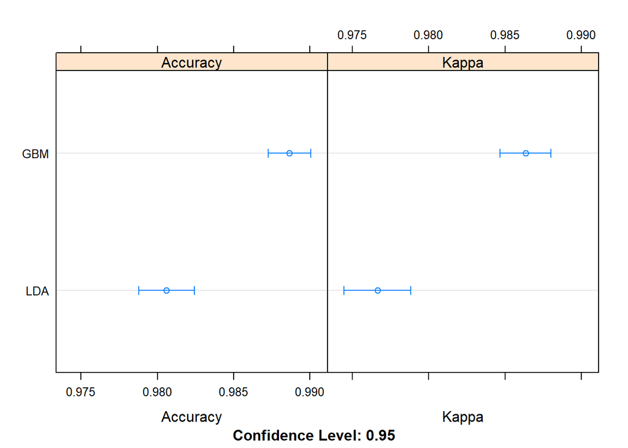

```r
dotplot(results)
```

## 6. Finalize Model and Present Results

Once we have narrow down to a model that we believe can make accurate predictions on unseen data, we are ready to finalize it. Finalizing a model may involve sub-tasks such as:

- Using an optimal model tuned to make predictions on unseen data.
- Creating a standalone model using the tuned parameters
- Saving an optimal model to file for later use.

### 6.a) Predictions on validation dataset

```r
predictions <- predict(fit.final2, newdata=validation)
confusionMatrix(predictions, validation$targetVar)
```

```
## Confusion Matrix and Statistics
##
##           Reference
## Prediction   1   2   3   4   5   6
##          1 494  28   8   0   0   0
##          2   1 435   8   2   0   0
##          3   1   5 396   0   0   0
##          4   0   0   0 443  23   0
##          5   0   3   8  46 509   0
##          6   0   0   0   0   0 537
##
## Overall Statistics
##
##                Accuracy : 0.9549
##                  95% CI : (0.9467, 0.9621)
##     No Information Rate : 0.1822
##     P-Value [Acc > NIR] : < 2.2e-16
##
##                   Kappa : 0.9457
##  Mcnemar's Test P-Value : NA
##
## Statistics by Class:
##
##                      Class: 1 Class: 2 Class: 3 Class: 4 Class: 5 Class: 6
## Sensitivity            0.9960   0.9236   0.9429   0.9022   0.9568   1.0000
## Specificity            0.9853   0.9956   0.9976   0.9906   0.9764   1.0000
## Pos Pred Value         0.9321   0.9753   0.9851   0.9506   0.8993   1.0000
## Neg Pred Value         0.9992   0.9856   0.9906   0.9807   0.9903   1.0000
## Prevalence             0.1683   0.1598   0.1425   0.1666   0.1805   0.1822
## Detection Rate         0.1676   0.1476   0.1344   0.1503   0.1727   0.1822
## Detection Prevalence   0.1798   0.1513   0.1364   0.1581   0.1921   0.1822
## Balanced Accuracy      0.9906   0.9596   0.9702   0.9464   0.9666   1.0000
```

### 6.b) Create standalone model on entire training dataset

```r
startTimeModule <- proc.time()
library(gbm)
set.seed(seedNum)
finalModel <- gbm(targetVar~., data=training, n.trees=1000, verbose=F)
```

```
## Distribution not specified, assuming multinomial ...
```

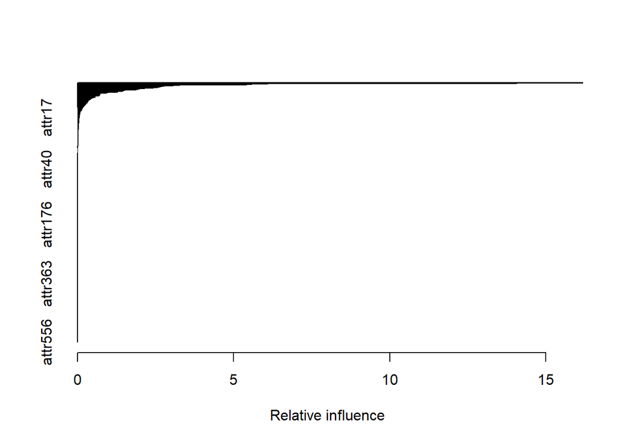

```
##             var      rel.inf
## attr53   attr53 1.617813e+01
## attr41   attr41 1.406125e+01
## attr505 attr505 6.085807e+00
## attr10   attr10 5.568632e+00
## attr560 attr560 5.411721e+00
## attr275 attr275 3.260985e+00
## attr130 attr130 3.059672e+00
## attr167 attr167 2.766079e+00
## attr54   attr54 2.674807e+00
## attr317 attr317 2.619691e+00
## attr297 attr297 2.560804e+00
## attr202 attr202 2.432013e+00
## attr451 attr451 2.137598e+00
## attr538 attr538 1.975163e+00
## attr331 attr331 1.917946e+00
## attr503 attr503 1.861522e+00
## attr139 attr139 1.511833e+00
## attr559 attr559 1.459416e+00
## attr519 attr519 1.428276e+00
## attr51   attr51 1.282926e+00
## attr372 attr372 1.272601e+00
## attr42   attr42 9.668817e-01
## attr509 attr509 9.250186e-01
## attr433 attr433 7.233257e-01
## attr430 attr430 7.185901e-01
## attr333 attr333 7.130574e-01
## attr296 attr296 7.107237e-01
## attr370 attr370 6.970646e-01
## attr90   attr90 6.813205e-01
## attr58   attr58 5.700255e-01
## attr311 attr311 5.663653e-01
## attr103 attr103 5.607682e-01
## attr303 attr303 5.083604e-01
## attr133 attr133 4.564177e-01
## attr375 attr375 4.252400e-01
## attr136 attr136 4.101398e-01
## attr319 attr319 4.060248e-01
## attr435 attr435 3.750655e-01
## attr70   attr70 3.481696e-01
```

[output cut: 507 more lines]

```
## attr540 attr540 0.000000e+00
## attr541 attr541 0.000000e+00
## attr542 attr542 0.000000e+00
## attr543 attr543 0.000000e+00
## attr544 attr544 0.000000e+00
## attr546 attr546 0.000000e+00
## attr547 attr547 0.000000e+00
## attr548 attr548 0.000000e+00
## attr549 attr549 0.000000e+00
## attr550 attr550 0.000000e+00
## attr551 attr551 0.000000e+00
## attr553 attr553 0.000000e+00
## attr554 attr554 0.000000e+00
## attr555 attr555 0.000000e+00
## attr556 attr556 0.000000e+00
```

```r
summary(finalModel)
```

```r
proc.time()-startTimeModule
```

```
##    user  system elapsed
##  438.80    0.70  439.92
```

### 6.c) Save model for later use

```r
#saveRDS(finalModel, "./finalModel_MultiClass.rds")
```

```r
proc.time()-startTimeScript
```

```
##     user   system  elapsed
## 77657.58   420.91 78157.48
```